# **TikTok Project**

**TikTok Case Study**

A Data Scientist at TikTok, is pleased with the work you have already completed and is requesting your assistance with some Exploratory Data Analysis (EDA) and data visualization. The management team asked to see a Python notebook showing data structuring and cleaning, as well as any matplotlib/seaborn visualizations plotted to help us understand the data. At the very least, include a graph comparing claim counts to opinion counts, as well as boxplots of the most important variables (like “video duration,” “video like count,” “video comment count,” and “video view count”) to check for outliers. Also, include a breakdown of “author ban status” counts.

Additionally, the management team has recently asked all EDA to include Tableau visualizations. Tableau visualizations are particularly helpful in status reports to the client and board members. For this data, create a Tableau dashboard showing a simple claims versus opinions count, as well as stacked bar charts of claims versus opinions for variables like video view counts, video like counts, video share counts, and video download counts. Make sure it is easy to understand to someone who isn’t data savvy, and remember that the assistant director is a person with visual impairments.

You also notice a follow-up email from the Data Science Lead, Willow Jaffey. Willow suggests including an executive summary of your analysis to share with teammates.

# **Exploratory data analysis**

In this activity, you will examine data provided and prepare it for analysis. You will also design a professional data visualization that tells a story, and will help data-driven decisions for business needs.

Please note that the Tableau visualization activity is optional, and will not affect your completion of the course. Completing the Tableau activity will help you practice planning out and plotting a data visualization based on a specific business need. The structure of this activity is designed to emulate the proposals you will likely be assigned in your career as a data professional. Completing this activity will help prepare you for those career moments.

**The purpose** of this project is to conduct exploratory data analysis on a provided data set. Your mission is to continue the investigation you began in C2 and perform further EDA on this data with the aim of learning more about the variables. Of particular interest is information related to what distinguishes claim videos from opinion videos.

**The goal** is to explore the dataset and create visualizations.  
*This activity has 4 parts:*

**Part 1:** Imports, links, and loading

**Part 2:** Data Exploration

- Data cleaning

**Part 3:** Build visualizations

**Part 4:** Evaluate and share results

# **Visualize a story in Tableau and Python**

### **Task 1. Imports, links, and loading**

Go to Tableau Public The following link will help you complete this activity. Keep Tableau Public open as you proceed to the next steps.

Link to supporting materials: Public Tableau: https://public.tableau.com/app/profile/kevin.proudler/viz/TikTokDataExploration/Story1.

For EDA of the data, import the packages that would be most helpful, such as `pandas`, `numpy`, `matplotlib.pyplot`, and `seaborn`.

```python
# Import packages for data manipulation
import pandas as pd
import numpy as np
import datetime as dt
# Import packages for data visualization
import matplotlib.pyplot as plt
import seaborn as sns
```

Then, load the dataset into a dataframe. Read in the data and store it as a dataframe object.

**Note:** As shown in this cell, the dataset has been automatically loaded in for you. You do not need to download the .csv file, or provide more code, in order to access the dataset and proceed with this lab. Please continue with this activity by completing the following instructions.

```python
# Load dataset into dataframe
data = pd.read_csv("tiktok_dataset.csv")
```

### **Task 2a: Data exploration and cleaning**

The first step is to assess your data. Check the Data Source page on Tableau Public to get a sense of the size, shape and makeup of the data set.

Consider functions that help you understand and structure the data.

- `.head()`
- `.info()`
- `.describe()`
- `.groupby()`
- `.sort_values()`

Consider the following questions as you work:

What do you do about missing data (if any)?

Are there data outliers?

```python
# Display and examine the first few rows of the dataframe

data.head()
```

|  | # | claim_status | video_id | video_duration_sec | video_transcription_text | verified_status | author_ban_status | video_view_count | video_like_count | video_share_count | video_download_count | video_comment_count |
| --- | --- | --- | --- | --- | --- | --- | --- | --- | --- | --- | --- | --- |
| 0 | 1 | claim | 7017666017 | 59 | someone shared with me that drone deliveries a... | not verified | under review | 343296.0 | 19425.0 | 241.0 | 1.0 | 0.0 |
| 1 | 2 | claim | 4014381136 | 32 | someone shared with me that there are more mic... | not verified | active | 140877.0 | 77355.0 | 19034.0 | 1161.0 | 684.0 |
| 2 | 3 | claim | 9859838091 | 31 | someone shared with me that american industria... | not verified | active | 902185.0 | 97690.0 | 2858.0 | 833.0 | 329.0 |
| 3 | 4 | claim | 1866847991 | 25 | someone shared with me that the metro of st. p... | not verified | active | 437506.0 | 239954.0 | 34812.0 | 1234.0 | 584.0 |
| 4 | 5 | claim | 7105231098 | 19 | someone shared with me that the number of busi... | not verified | active | 56167.0 | 34987.0 | 4110.0 | 547.0 | 152.0 |

```python
# Get the size of the data

data.size
```

```
232584
```

```python
# Get the shape of the data

data.shape
```

```
(19382, 12)
```

Get basic information about the data, using `.info()`.

```python
# Get basic information about the data

data.info()
```

```
<class 'pandas.core.frame.DataFrame'>
RangeIndex: 19382 entries, 0 to 19381
Data columns (total 12 columns):
 #   Column                    Non-Null Count  Dtype
---  ------                    --------------  -----
 0   #                         19382 non-null  int64
 1   claim_status              19084 non-null  object
 2   video_id                  19382 non-null  int64
 3   video_duration_sec        19382 non-null  int64
 4   video_transcription_text  19084 non-null  object
 5   verified_status           19382 non-null  object
 6   author_ban_status         19382 non-null  object
 7   video_view_count          19084 non-null  float64
 8   video_like_count          19084 non-null  float64
 9   video_share_count         19084 non-null  float64
 10  video_download_count      19084 non-null  float64
 11  video_comment_count       19084 non-null  float64
dtypes: float64(5), int64(3), object(4)
memory usage: 1.8+ MB
```

Generate a table of descriptive statistics, using `.describe()`.

```python
# Generate a table of descriptive statistics

data.describe()
```

|  | # | video_id | video_duration_sec | video_view_count | video_like_count | video_share_count | video_download_count | video_comment_count |
| --- | --- | --- | --- | --- | --- | --- | --- | --- |
| count | 19382.000000 | 1.938200e+04 | 19382.000000 | 19084.000000 | 19084.000000 | 19084.000000 | 19084.000000 | 19084.000000 |
| mean | 9691.500000 | 5.627454e+09 | 32.421732 | 254708.558688 | 84304.636030 | 16735.248323 | 1049.429627 | 349.312146 |
| std | 5595.245794 | 2.536440e+09 | 16.229967 | 322893.280814 | 133420.546814 | 32036.174350 | 2004.299894 | 799.638865 |
| min | 1.000000 | 1.234959e+09 | 5.000000 | 20.000000 | 0.000000 | 0.000000 | 0.000000 | 0.000000 |
| 25% | 4846.250000 | 3.430417e+09 | 18.000000 | 4942.500000 | 810.750000 | 115.000000 | 7.000000 | 1.000000 |
| 50% | 9691.500000 | 5.618664e+09 | 32.000000 | 9954.500000 | 3403.500000 | 717.000000 | 46.000000 | 9.000000 |
| 75% | 14536.750000 | 7.843960e+09 | 47.000000 | 504327.000000 | 125020.000000 | 18222.000000 | 1156.250000 | 292.000000 |
| max | 19382.000000 | 9.999873e+09 | 60.000000 | 999817.000000 | 657830.000000 | 256130.000000 | 14994.000000 | 9599.000000 |

### **Task 3. Build visualizations**

Various visualizations about the data for further exploration

#### **video_duration_sec**

Create a box plot to examine the spread of values in the `video_duration_sec` column.

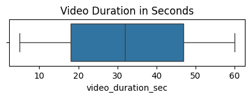

```python
# Create a boxplot to visualize distribution of `video_duration_sec`

plt.figure(figsize=(5,1))
plt.title('Video Duration in Seconds')
sns.boxplot(x=data['video_duration_sec']);
```

Create a histogram of the values in the `video_duration_sec` column to further explore the distribution of this variable.

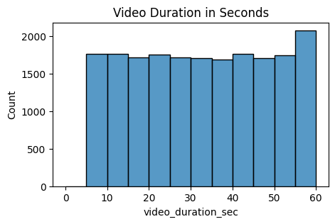

```python
# Create a histogram

plt.figure(figsize=(5,3))
plt.title('Video Duration in Seconds')
sns.histplot(x=data['video_duration_sec'], bins=range(0,61,5));
```

The histogram reveals that there is a very even distribution accross video lengths from 5-60 seconds.

#### **video_view_count**

Create a box plot to examine the spread of values in the `video_view_count` column.

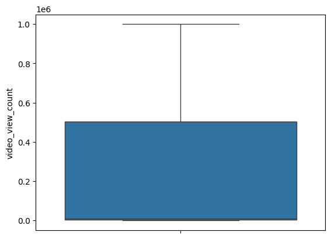

```python
# Create a boxplot to visualize distribution of `video_view_count`

sns.boxplot(data=data, y='video_view_count');
```

Create a histogram of the values in the `video_view_count` column to further explore the distribution of this variable.

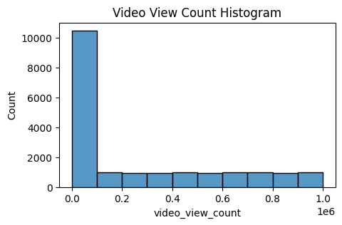

```python
# Create a histogram

plt.figure(figsize=(5,3))
sns.histplot(x=data['video_view_count'], bins=range(0,(10**6+1), 10**5))
plt.title('Video View Count Histogram');
```

There is a high number of videos with a view count of 100k or less. Beyond that, there is an even distribution.

#### **video_like_count**

Create a box plot to examine the spread of values in the `video_like_count` column.

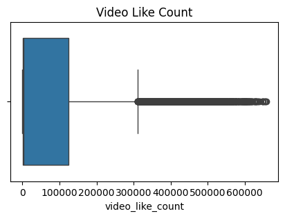

```python
# Create a boxplot to visualize distribution of `video_like_count`

plt.figure(figsize=(5,3))
plt.title('Video Like Count')
sns.boxplot(x=data['video_like_count']);
```

Create a histogram of the values in the `video_like_count` column to further explore the distribution of this variable.

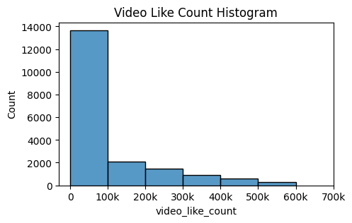

```python
# Create a histogram

plt.figure(figsize=(5,3))
ax = sns.histplot(x=data['video_like_count'], bins=range(0,700000,100000))
labels = [0] + [str(i) + 'k' for i in range(100,701,100)]
ax.set_xticks(range(0,7*10**5+1,10**5), labels=labels)
plt.title('Video Like Count Histogram');
```

#### **video_comment_count**

Create a box plot to examine the spread of values in the `video_comment_count` column.

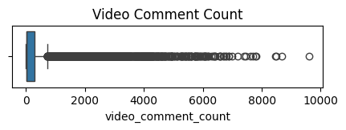

```python
# Create a boxplot to visualize distribution of `video_comment_count`

plt.figure(figsize=(5,1))
plt.title('Video Comment Count')
sns.boxplot(x=data['video_comment_count']);
```

Create a histogram of the values in the `video_comment_count` column to further explore the distribution of this variable.

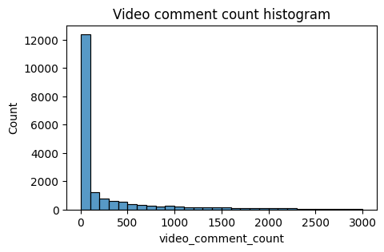

```python
# Create a histogram

plt.figure(figsize=(5,3))
sns.histplot(data['video_comment_count'], bins=range(0,(3001),100))
plt.title('Video comment count histogram');
```

#### **video_share_count**

Create a box plot to examine the spread of values in the `video_share_count` column.

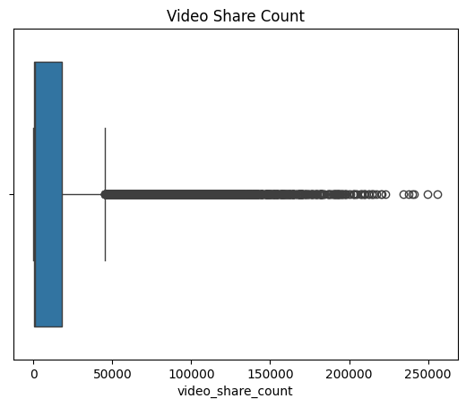

```python
# Create a boxplot to visualize distribution of `video_share_count`

sns.boxplot(x=data['video_share_count'])
plt.title("Video Share Count");
```

*Create* a histogram of the values in the `video_share_count` column to further explore the distribution of this variable.

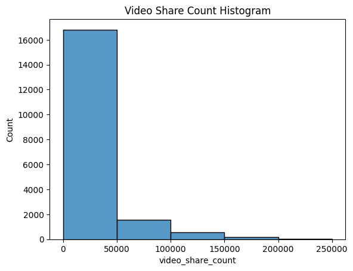

```python
# Create a histogram

plt.title('Video Share Count Histogram')
sns.histplot(x=data['video_share_count'], bins=range(0,250001,50000));
```

As one might expect, the vast majority of videos have very little shares.

#### **video_download_count**

Create a box plot to examine the spread of values in the `video_download_count` column.

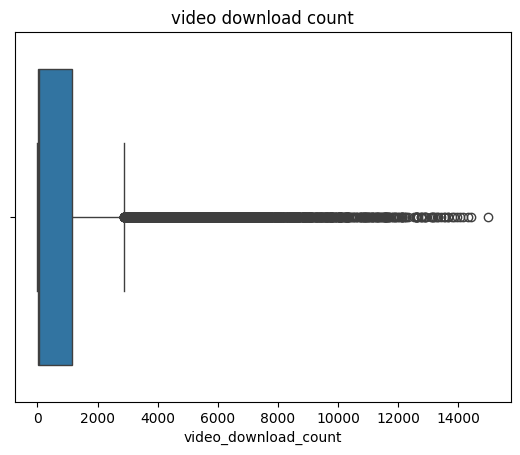

```python
# Create a boxplot to visualize distribution of `video_download_count`

plt.title('video download count')
sns.boxplot(x=data['video_download_count']);
```

Create a histogram of the values in the `video_download_count` column to further explore the distribution of this variable.

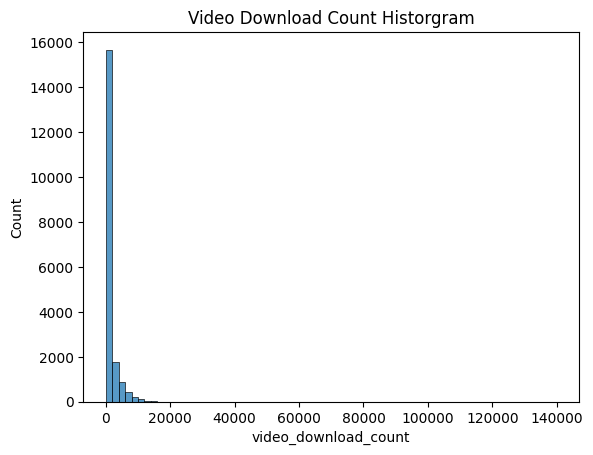

```python
# Create a histogram

plt.title('Video Download Count Historgram')
sns.histplot(x=data['video_download_count'], bins=range(0,140001,2000));
```

Similar to shares, the video download count is heavily skewed towards 0

#### **Claim status by verification status**

Now, create a histogram with four bars: one for each combination of claim status and verification status.

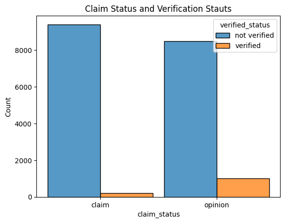

```python
# Create a histogram

plt.title('Claim Status and Verification Stauts')
sns.histplot(data=data,
             x='claim_status',
             hue='verified_status',
             multiple='dodge',
             shrink=0.9);
```

What we notice here is that of the claim videos, a very small proportion of the videos are coming from verified users. Comparatively, the proportion of opinion videos that are coming from verified users is much larger.

#### **Claim status by author ban status**

The previous course used a `groupby()` statement to examine the count of each claim status for each author ban status. Now, use a histogram to communicate the same information.

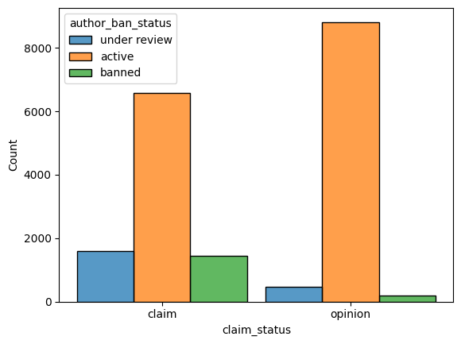

```python
# Create a histogram

sns.histplot(data=data,
             x='claim_status',
             hue='author_ban_status',
             multiple='dodge',
             shrink=0.9
             );
```

#### **Median view counts by ban status**

Create a bar plot with three bars: one for each author ban status. The height of each bar should correspond with the median number of views for all videos with that author ban status.

[output not shown]

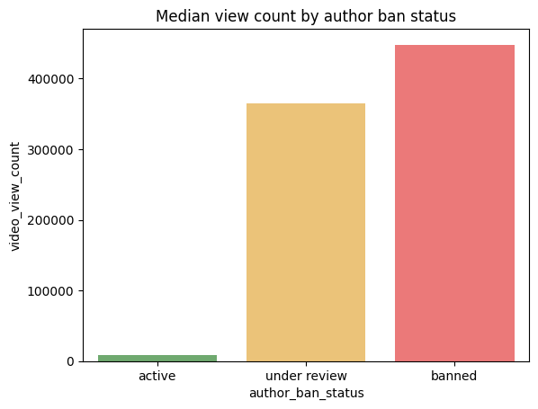

```python
# Create a bar plot

ban_status_count = data.groupby(['author_ban_status']).median(numeric_only=True).reset_index()
sns.barplot(data=ban_status_count,
            y='video_view_count',
            x='author_ban_status',
            order=['active', 'under review', 'banned'],
            palette={'active': 'green', 'under review': 'orange', 'banned': 'red'},
            alpha=0.6)
plt.title('Median view count by author ban status');
```

Based on the median view counts, video view count may be a potential indicator for author claim status.

```python
# Calculate the median view count for claim status.

data.groupby('claim_status')['video_view_count'].median()
```

```
claim_status
claim      501555.0
opinion      4953.0
Name: video_view_count, dtype: float64
```

#### **Total views by claim status**

Create a pie graph that depicts the proportions of total views for claim videos and total views for opinion videos.

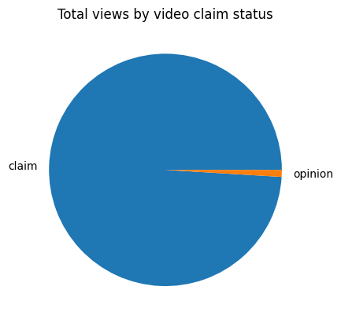

```python
# Create a pie graph

plt.pie(data.groupby('claim_status')['video_view_count'].sum(), labels=['claim', 'opinion'])
plt.title('Total views by video claim status');
```

### **Task 4. Determine outliers**

The ultimate objective of the TikTok project is to build a model that predicts whether a video is a claim or opinion. The analysis you've performed indicates that a video's engagement level is strongly correlated with its claim status. There's no reason to believe that any of the values in the TikTok data are erroneously captured, and they align with expectation of how social media works: a very small proportion of videos get super high engagement levels. That's the nature of viral content.

Nonetheless, it's good practice to get a sense of just how many of your data points could be considered outliers. The definition of an outlier can change based on the details of your project, and it helps to have domain expertise to decide a threshold. You've learned that a common way to determine outliers in a normal distribution is to calculate the interquartile range (IQR) and set a threshold that is 1.5 * IQR above the 3rd quartile.

In this TikTok dataset, the values for the count variables are not normally distributed. They are heavily skewed to the right. One way of modifying the outlier threshold is by calculating the **median** value for each variable and then adding 1.5 * IQR. This results in a threshold that is, in this case, much lower than it would be if you used the 3rd quartile.

Write a for loop that iterates over the column names of each count variable. For each iteration:

1. Calculate the IQR of the column
2. Calculate the median of the column
3. Calculate the outlier threshold (median + 1.5 * IQR)
4. Calculate the numer of videos with a count in that column that exceeds the outlier threshold
5. Print "Number of outliers, {column name}: {outlier count}"

```python
count_cols = ['video_view_count',
              'video_like_count',
              'video_share_count',
              'video_download_count',
              'video_comment_count',
              ]
for column in count_cols:
    q1 = data[column].quantile(0.25)
    q3 = data[column].quantile(0.75)
    iqr = q3 - q1
    median = data[column].median()
    outlier_threshold = median + 1.5*iqr
    outlier_count = (data[column] > outlier_threshold).sum()

    print(f'Number of outliers, {column}: {outlier_count}')
```

```
Number of outliers, video_view_count: 2343
Number of outliers, video_like_count: 3468
Number of outliers, video_share_count: 3732
Number of outliers, video_download_count: 3733
Number of outliers, video_comment_count: 3882
```

#### **Scatterplot**

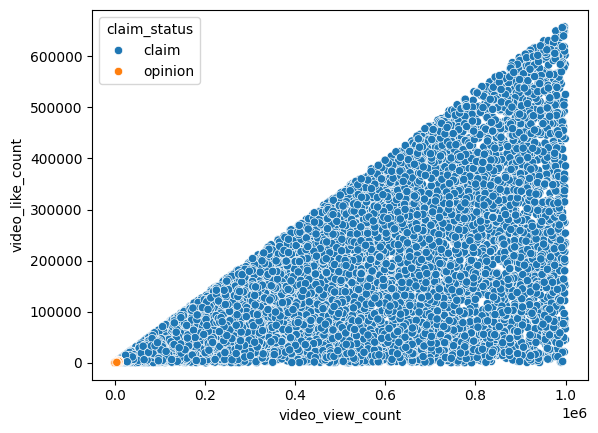

```python
# Create a scatterplot of `video_view_count` versus `video_like_count` according to 'claim_status'

sns.scatterplot(
    data=data,
    x='video_view_count',
    y='video_like_count',
    hue='claim_status'
)
```

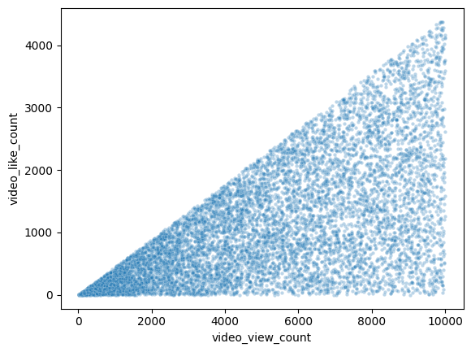

```python
# Create a scatterplot of ``video_view_count` versus `video_like_count` for opinions only

opinion = data[data['claim_status'] == 'opinion']
sns.scatterplot(
    x=opinion['video_view_count'],
    y=opinion['video_like_count'],
    s=10,
    alpha=0.3
);
```

### **Task 5b. Conclusion**

I examined the data distribution/spread, count frequencies, mean and median values, extreme values/outliers, missing data, and more. I analyzed correlations between variables, particularly between the claim_status variable and others.

I want to further investigate distinctive characteristics that apply only to claims or only to opinions. Also, I want to consider other variables that might be helpful in understanding the data.

The assumptions regarding what might be predictive data of claim_status will be the end goal upon further analysis for the client.